# Return Home

[View Code on Github](https://github.com/JohnKimaiyo/Data-Analysis-Projects/blob/main/Python/Youtube%20Data%20API/Top%20Documentaries%20You%20Tube%20Channels.ipynb)

# Top Documentaries You Tube Channels

## 1 Timeline - World History Documentaries

Welcome to Timeline - the home of world history. Every week we'll be bringing you one-off documentaries and series from the world's top broadcasters, including the BBC, Channel 4, Discovery and PBS.

## 2 DW Documentary

DW Documentary gives you information beyond the headlines. Watch top documentaries from German broadcasters and international production companies. Meet intriguing people, travel to distant lands, get a look behind the complexities of daily life and build a deeper understanding of current affairs and global events. Subscribe and explore the world around you with DW Documentary from Deutsche Welle (DW), Germany's international broadcaster

## 4 Journeyman Pictures

Do you want to know more? For over 20 years Journeyman Pictures have independently distributed the world's most provocative, incisive factual TV. Working with the top players in the industry, our award-winning stories put us at the spearhead of the factual agenda. We're your independent source for the world's most powerful films, exploring the burning issues of today

## 5 60 Minutes

"60 Minutes," the most successful television broadcast in history. Offering hard-hitting investigative reports, interviews, feature segments and profiles of people in the news, the broadcast began in 1968 and is still a hit, over 50 seasons later, regularly making Nielsen's Top 10.

## 6 VICE

Enlightening commentary, authoritative advice, and unique stories you won't find anywhere else. Our immersive and ground-breaking storytelling has changed the way people think about culture, crime, art, parties, fashion, protest, the internet and other subjects that don't even have names yet. Browse the library and discover corners of the world you never knew existed.

```python
# lets import libraries
from googleapiclient.discovery import build
import pandas as pd
import seaborn as sn
```

## 1 Timeline - World History Documentaries

```python
# Function to get channel statistics
api_key = 'AIzaSyB24Kop04L1GlTgRCm1XtQ4KB2a4gaBOwA'
Timeline_channel_id = ['UC88lvyJe7aHZmcvzvubDFRg' # Timeline - World History Documentaries

              ]
youtube = build('youtube','v3',developerKey = api_key)

from googleapiclient.errors import HttpError

def get_channel_stats(youtube, Timeline_channel_id):
    all_data = []
    try:
        request = youtube.channels().list(
            part='snippet,contentDetails,statistics',
            id=','.join(Timeline_channel_id)
        )
        response = request.execute()

        for item in response.get('items', []):
            snippet = item.get('snippet', {})
            statistics = item.get('statistics', {})

            data = {
                'Channel_name': snippet.get('title', ''),
                'Subscribers': statistics.get('subscriberCount', ''),
                'Views': statistics.get('viewCount', ''),
                'Total_videos': statistics.get('videoCount', '')
            }

            all_data.append(data)

    except HttpError as e:
        print(f"HTTP error occurred: {e}")
        print(f"Request URL: {e.resp.request.url}")
        print(f"Request body: {e.resp.request.body}")

    return all_data
```

```python
get_channel_stats(youtube,Timeline_channel_id)
```

```
[{'Channel_name': 'Timeline - World History Documentaries',
  'Subscribers': '5120000',
  'Views': '1173285359',
  'Total_videos': '1235'}]
```

```python
channel_statistics = get_channel_stats(youtube, Timeline_channel_id)
```

```python
Timeline_channel_data =pd.DataFrame(channel_statistics)
```

```python
Timeline_channel_data
```

|  | Channel_name | Subscribers | Views | Total_videos |
| --- | --- | --- | --- | --- |
| 0 | Timeline - World History Documentaries | 5120000 | 1173285359 | 1235 |

## 2 DW Documentary

```python
# Function to get channel statistics
api_key = 'AIzaSyB24Kop04L1GlTgRCm1XtQ4KB2a4gaBOwA'
DW_Documentary_channel_id = ['UCW39zufHfsuGgpLviKh297Q' #  DW Documentary

              ]
youtube = build('youtube','v3',developerKey = api_key)

from googleapiclient.errors import HttpError

def get_channel_stats(youtube, DW_Documentary_channel_id):
    all_data = []
    try:
        request = youtube.channels().list(
            part='snippet,contentDetails,statistics',
            id=','.join(DW_Documentary_channel_id)
        )
        response = request.execute()

        for item in response.get('items', []):
            snippet = item.get('snippet', {})
            statistics = item.get('statistics', {})

            data = {
                'Channel_name': snippet.get('title', ''),
                'Subscribers': statistics.get('subscriberCount', ''),
                'Views': statistics.get('viewCount', ''),
                'Total_videos': statistics.get('videoCount', '')
            }

            all_data.append(data)

    except HttpError as e:
        print(f"HTTP error occurred: {e}")
        print(f"Request URL: {e.resp.request.url}")
        print(f"Request body: {e.resp.request.body}")

    return all_data
```

```python
get_channel_stats(youtube,DW_Documentary_channel_id)
```

```
[{'Channel_name': 'DW Documentary',
  'Subscribers': '5390000',
  'Views': '788340346',
  'Total_videos': '1071'}]
```

```python
channel_statistics = get_channel_stats(youtube, DW_Documentary_channel_id)
```

```python
DW_Documentary_channel_data =pd.DataFrame(channel_statistics)
```

```python
DW_Documentary_channel_data
```

|  | Channel_name | Subscribers | Views | Total_videos |
| --- | --- | --- | --- | --- |
| 0 | DW Documentary | 5390000 | 788340346 | 1071 |

```python
# Function to get channel statistics
api_key = 'AIzaSyB24Kop04L1GlTgRCm1XtQ4KB2a4gaBOwA'
Free_Documentary_channel_id = ['UCBnFes2U2diA3QfR5m8l_Tw' # JPMorgan Chase

              ]
youtube = build('youtube','v3',developerKey = api_key)

from googleapiclient.errors import HttpError

def get_channel_stats(youtube, Free_Documentary_channel_id):
    all_data = []
    try:
        request = youtube.channels().list(
            part='snippet,contentDetails,statistics',
            id=','.join(Free_Documentary_channel_id)
        )
        response = request.execute()

        for item in response.get('items', []):
            snippet = item.get('snippet', {})
            statistics = item.get('statistics', {})

            data = {
                'Channel_name': snippet.get('title', ''),
                'Subscribers': statistics.get('subscriberCount', ''),
                'Views': statistics.get('viewCount', ''),
                'Total_videos': statistics.get('videoCount', '')
            }

            all_data.append(data)

    except HttpError as e:
        print(f"HTTP error occurred: {e}")
        print(f"Request URL: {e.resp.request.url}")
        print(f"Request body: {e.resp.request.body}")

    return all_data
```

```python
get_channel_stats(youtube,Free_Documentary_channel_id)
```

```
[{'Channel_name': 'jpmorgan',
  'Subscribers': '102000',
  'Views': '41976005',
  'Total_videos': '970'}]
```

```python
channel_statistics = get_channel_stats(youtube, Free_Documentary_channel_id)
```

```python
Free_Documentary_channel_data =pd.DataFrame(channel_statistics)
```

```python
Free_Documentary_channel_data
```

|  | Channel_name | Subscribers | Views | Total_videos |
| --- | --- | --- | --- | --- |
| 0 | jpmorgan | 102000 | 41976005 | 970 |

## 4 Journeyman Pictures

```python
# Function to get channel statistics
api_key = 'AIzaSyB24Kop04L1GlTgRCm1XtQ4KB2a4gaBOwA'
Journeyman_Pictures_channel_id = ['UCM2YmsRUeIbRkqjgNm0eTGQ' #  Journeyman Pictures

              ]
youtube = build('youtube','v3',developerKey = api_key)

from googleapiclient.errors import HttpError

def get_channel_stats(youtube, Journeyman_Pictures_channel_id):
    all_data = []
    try:
        request = youtube.channels().list(
            part='snippet,contentDetails,statistics',
            id=','.join(Journeyman_Pictures_channel_id)
        )
        response = request.execute()

        for item in response.get('items', []):
            snippet = item.get('snippet', {})
            statistics = item.get('statistics', {})

            data = {
                'Channel_name': snippet.get('title', ''),
                'Subscribers': statistics.get('subscriberCount', ''),
                'Views': statistics.get('viewCount', ''),
                'Total_videos': statistics.get('videoCount', '')
            }

            all_data.append(data)

    except HttpError as e:
        print(f"HTTP error occurred: {e}")
        print(f"Request URL: {e.resp.request.url}")
        print(f"Request body: {e.resp.request.body}")

    return all_data
```

```python
get_channel_stats(youtube,Journeyman_Pictures_channel_id)
```

```
[{'Channel_name': 'Journeyman Pictures',
  'Subscribers': '2350000',
  'Views': '881489991',
  'Total_videos': '8713'}]
```

```python
channel_statistics = get_channel_stats(youtube, Journeyman_Pictures_channel_id)
```

```python
Journeyman_Pictures_channel_data =pd.DataFrame(channel_statistics)
```

```python
Journeyman_Pictures_channel_data
```

|  | Channel_name | Subscribers | Views | Total_videos |
| --- | --- | --- | --- | --- |
| 0 | Journeyman Pictures | 2350000 | 881489991 | 8713 |

## 5 60 Minutes

```python
# Function to get channel statistics
api_key = 'AIzaSyB24Kop04L1GlTgRCm1XtQ4KB2a4gaBOwA'
sixty_channel_id = ['UCsN32BtMd0IoByjJRNF12cw' # 60 Minutes

              ]
youtube = build('youtube','v3',developerKey = api_key)

from googleapiclient.errors import HttpError

def get_channel_stats(youtube, sixty_channel_id):
    all_data = []
    try:
        request = youtube.channels().list(
            part='snippet,contentDetails,statistics',
            id=','.join(sixty_channel_id)
        )
        response = request.execute()

        for item in response.get('items', []):
            snippet = item.get('snippet', {})
            statistics = item.get('statistics', {})

            data = {
                'Channel_name': snippet.get('title', ''),
                'Subscribers': statistics.get('subscriberCount', ''),
                'Views': statistics.get('viewCount', ''),
                'Total_videos': statistics.get('videoCount', '')
            }

            all_data.append(data)

    except HttpError as e:
        print(f"HTTP error occurred: {e}")
        print(f"Request URL: {e.resp.request.url}")
        print(f"Request body: {e.resp.request.body}")

    return all_data
```

```python
get_channel_stats(youtube,sixty_channel_id)
```

```
[{'Channel_name': '60 Minutes',
  'Subscribers': '2660000',
  'Views': '742789912',
  'Total_videos': '3193'}]
```

```python
channel_statistics = get_channel_stats(youtube, sixty_channel_id)
```

```python
sixty_channel_data =pd.DataFrame(channel_statistics)
```

```python
sixty_channel_data
```

|  | Channel_name | Subscribers | Views | Total_videos |
| --- | --- | --- | --- | --- |
| 0 | 60 Minutes | 2660000 | 742789912 | 3193 |

## 6 VICE

```python
# Function to get channel statistics
api_key = 'AIzaSyB24Kop04L1GlTgRCm1XtQ4KB2a4gaBOwA'
VICE_channel_id = ['UCn8zNIfYAQNdrFRrr8oibKw' # VICE

              ]
youtube = build('youtube','v3',developerKey = api_key)

from googleapiclient.errors import HttpError

def get_channel_stats(youtube, VICE_channel_id):
    all_data = []
    try:
        request = youtube.channels().list(
            part='snippet,contentDetails,statistics',
            id=','.join(VICE_channel_id)
        )
        response = request.execute()

        for item in response.get('items', []):
            snippet = item.get('snippet', {})
            statistics = item.get('statistics', {})

            data = {
                'Channel_name': snippet.get('title', ''),
                'Subscribers': statistics.get('subscriberCount', ''),
                'Views': statistics.get('viewCount', ''),
                'Total_videos': statistics.get('videoCount', '')
            }

            all_data.append(data)

    except HttpError as e:
        print(f"HTTP error occurred: {e}")
        print(f"Request URL: {e.resp.request.url}")
        print(f"Request body: {e.resp.request.body}")

    return all_data
```

```python
get_channel_stats(youtube, VICE_channel_id)
```

```
[{'Channel_name': 'VICE',
  'Subscribers': '17900000',
  'Views': '4942326231',
  'Total_videos': '4029'}]
```

```python
channel_statistics = get_channel_stats(youtube,VICE_channel_id)
```

```python
VICE_channel_data =pd.DataFrame(channel_statistics)
```

```python
VICE_channel_data
```

|  | Channel_name | Subscribers | Views | Total_videos |
| --- | --- | --- | --- | --- |
| 0 | VICE | 17900000 | 4942326231 | 4029 |

```python
# Lets combine the data frames
# Combine DataFrames using concat
combined_documentaries_channels_df = pd.concat([Timeline_channel_data ,
                                       DW_Documentary_channel_data  ,
                                     Free_Documentary_channel_data ,
                                      Journeyman_Pictures_channel_data ,
                                     sixty_channel_data,
                                        VICE_channel_data
                                                                                ], ignore_index=True)

# Display the result
print(combined_documentaries_channels_df)
```

```
                             Channel_name Subscribers       Views Total_videos
0  Timeline - World History Documentaries     5120000  1173285359         1235
1                          DW Documentary     5390000   788340346         1071
2                                jpmorgan      102000    41976005          970
3                     Journeyman Pictures     2350000   881489991         8713
4                              60 Minutes     2660000   742789912         3193
5                                    VICE    17900000  4942326231         4029
```

```python
# # lets have  a look at the datatypes
combined_documentaries_channels_df.info()
```

```
<class 'pandas.core.frame.DataFrame'>
RangeIndex: 6 entries, 0 to 5
Data columns (total 4 columns):
 #   Column        Non-Null Count  Dtype
---  ------        --------------  -----
 0   Channel_name  6 non-null      object
 1   Subscribers   6 non-null      object
 2   Views         6 non-null      object
 3   Total_videos  6 non-null      object
dtypes: object(4)
memory usage: 324.0+ bytes
```

```python
# lets change the datatypes to perform  visualisations
combined_documentaries_channels_df['Subscribers'] = pd.to_numeric(combined_documentaries_channels_df['Subscribers'])
combined_documentaries_channels_df['Views'] = pd.to_numeric(combined_documentaries_channels_df['Views'])
combined_documentaries_channels_df['Total_videos'] = pd.to_numeric(combined_documentaries_channels_df['Total_videos'])
# letsconirm if the datatypes has changed
combined_documentaries_channels_df.info()
```

```
<class 'pandas.core.frame.DataFrame'>
RangeIndex: 6 entries, 0 to 5
Data columns (total 4 columns):
 #   Column        Non-Null Count  Dtype
---  ------        --------------  -----
 0   Channel_name  6 non-null      object
 1   Subscribers   6 non-null      int64
 2   Views         6 non-null      int64
 3   Total_videos  6 non-null      int64
dtypes: int64(3), object(1)
memory usage: 324.0+ bytes
```

```python
combined_documentaries_channels_df
```

|  | Channel_name | Subscribers | Views | Total_videos |
| --- | --- | --- | --- | --- |
| 0 | Timeline - World History Documentaries | 5120000 | 1173285359 | 1235 |
| 1 | DW Documentary | 5390000 | 788340346 | 1071 |
| 2 | jpmorgan | 102000 | 41976005 | 970 |
| 3 | Journeyman Pictures | 2350000 | 881489991 | 8713 |
| 4 | 60 Minutes | 2660000 | 742789912 | 3193 |
| 5 | VICE | 17900000 | 4942326231 | 4029 |

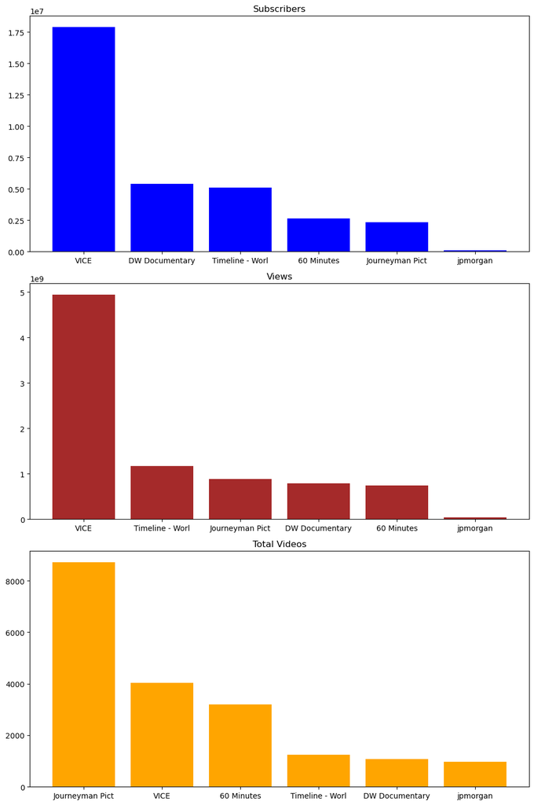

```python
import pandas as pd
import matplotlib.pyplot as plt

# Sort the DataFrame by 'Subscribers' in descending order
combined_documentaries_channels_df_subscribers_sorted = combined_documentaries_channels_df.sort_values(by='Subscribers', ascending=False)

# Shorten channel names
combined_documentaries_channels_df_subscribers_sorted['Channel_name'] =combined_documentaries_channels_df_subscribers_sorted['Channel_name'].apply(lambda x: x[:15])

# Plotting Subscribers in descending order
fig, axes = plt.subplots(nrows=3, ncols=1, figsize=(10, 15))

axes[0].bar(combined_documentaries_channels_df_subscribers_sorted['Channel_name'], combined_documentaries_channels_df_subscribers_sorted['Subscribers'], color='blue')
axes[0].set_title('Subscribers')

# Sort the DataFrame by 'Views' in descending order
combined_documentaries_channels_df_views_sorted = combined_documentaries_channels_df.sort_values(by='Views', ascending=False)

# Shorten channel names
combined_documentaries_channels_df_views_sorted['Channel_name'] = combined_documentaries_channels_df_views_sorted['Channel_name'].apply(lambda x: x[:15])

# Plotting Views in descending order
axes[1].bar(combined_documentaries_channels_df_views_sorted['Channel_name'],combined_documentaries_channels_df_views_sorted['Views'], color='brown')
axes[1].set_title('Views')

# Sort the DataFrame by 'Total_videos' in descending order
combined_documentaries_channels_df_total_videos_sorted =combined_documentaries_channels_df.sort_values(by='Total_videos', ascending=False)

# Shorten channel names
combined_documentaries_channels_df_total_videos_sorted['Channel_name'] = combined_documentaries_channels_df_total_videos_sorted['Channel_name'].apply(lambda x: x[:15])

# Plotting Total Videos in descending order
axes[2].bar(combined_documentaries_channels_df_total_videos_sorted['Channel_name'], combined_documentaries_channels_df_total_videos_sorted['Total_videos'], color='orange')
axes[2].set_title('Total Videos')

# Adjust layout for better visibility
plt.tight_layout()

# Show the plot
plt.show()
```